# New York City Shootings Data Analysis

2024-09-17

The following report is a data analysis of shooting incidents that occured in New York City’s boroughs. The data set gathered by the police department includes information pertaining to the time, date, location and demographics of both parties involved in each incident. You can reproduce the analysis by downloading the dataset “NYPD Shooting Incident Data (Hisoric)” from the www.data.gov website and following the code below.

```r
knitr::opts_chunk$set(echo = TRUE)
library(tidyverse)
library(hms)
```

```r
library(ggplot2)
library(lubridate)
library(isoband)
library(ggmap)
library(ggplot2)
library(dplyr)
library(viridis)
library(leaflet)
library(mgcv)
library(lattice)
library(nnet)
```

## Importing Data / Editing dataset

```r
data <- read.csv("https://data.cityofnewyork.us/api/views/833y-fsy8/rows.csv?accessType=DOWNLOAD")
head(data)
```

```
##   INCIDENT_KEY OCCUR_DATE OCCUR_TIME      BORO LOC_OF_OCCUR_DESC PRECINCT
## 1    244608249 05/05/2022   00:10:00 MANHATTAN            INSIDE       14
## 2    247542571 07/04/2022   22:20:00     BRONX           OUTSIDE       48
## 3     84967535 05/27/2012   19:35:00    QUEENS                        103
## 4    202853370 09/24/2019   21:00:00     BRONX                         42
## 5     27078636 02/25/2007   21:00:00  BROOKLYN                         83
## 6    230311078 07/01/2021   23:07:00 MANHATTAN                         23
##   JURISDICTION_CODE LOC_CLASSFCTN_DESC             LOCATION_DESC
## 1                 0         COMMERCIAL               VIDEO STORE
## 2                 0             STREET                    (null)
## 3                 0
## 4                 0
## 5                 0
## 6                 2                    MULTI DWELL - PUBLIC HOUS
##   STATISTICAL_MURDER_FLAG PERP_AGE_GROUP PERP_SEX PERP_RACE VIC_AGE_GROUP
```

[output cut: 20 more lines]

```r
# Review data set with head(data) and colnames(data)

df <- data %>%
  select("OCCUR_DATE", "OCCUR_TIME", "BORO", "LOC_OF_OCCUR_DESC", "PRECINCT",
         "LOC_CLASSFCTN_DESC", "LOCATION_DESC", "PERP_AGE_GROUP",
         "PERP_SEX", "PERP_RACE", "VIC_AGE_GROUP", "VIC_SEX", "VIC_RACE", "X_COORD_CD", "Y_COORD_CD","Latitude", "Longitude", "Lon_Lat" ) %>%
  mutate(
    BORO = as.factor(BORO),
    LOC_OF_OCCUR_DESC = as.factor(LOC_OF_OCCUR_DESC),
    PRECINCT = as.factor(PRECINCT),
    LOC_CLASSFCTN_DESC = as.factor(LOC_CLASSFCTN_DESC),
    LOCATION_DESC = as.factor(LOCATION_DESC),
    PERP_AGE_GROUP = as.factor(PERP_AGE_GROUP),
    PERP_SEX = as.factor(PERP_SEX),
    PERP_RACE = as.factor(PERP_RACE),
    VIC_AGE_GROUP = as.factor(VIC_AGE_GROUP),
    VIC_SEX = as.factor(VIC_SEX),
    VIC_RACE = as.factor(VIC_RACE)
  )

# Create a new column for the number of shootings
df <- df %>%
  add_count(BORO, name = "BORO_COUNT") %>%
  relocate(BORO) %>%
  relocate(BORO_COUNT, .after = BORO)

# Edit time and date variables
df <- df %>%
  mutate(OCCUR_DATE = gsub("^2023-", "", gsub("T.*", "", OCCUR_DATE)))

df <- df %>%
  mutate(OCCUR_TIME = gsub(":00$", "", OCCUR_TIME))

MONTHLY_COUNTS <- df %>%
  mutate(MONTH = substr(OCCUR_DATE, 1, 2)) %>%
  group_by(MONTH, BORO) %>%
  summarise(INCIDENT_COUNT = n(), .groups = "drop")

# Review dataset with head(df)
head(df)
```

```
##        BORO BORO_COUNT OCCUR_DATE OCCUR_TIME LOC_OF_OCCUR_DESC PRECINCT
## 1 MANHATTAN       3762 05/05/2022      00:10            INSIDE       14
## 2     BRONX       8376 07/04/2022      22:20           OUTSIDE       48
## 3    QUEENS       4271 05/27/2012      19:35                        103
## 4     BRONX       8376 09/24/2019      21:00                         42
## 5  BROOKLYN      11346 02/25/2007      21:00                         83
## 6 MANHATTAN       3762 07/01/2021      23:07                         23
##   LOC_CLASSFCTN_DESC             LOCATION_DESC PERP_AGE_GROUP PERP_SEX
## 1         COMMERCIAL               VIDEO STORE          25-44        M
## 2             STREET                    (null)         (null)   (null)
## 3
## 4                                                       25-44        M
## 5                                                       25-44        M
## 6                    MULTI DWELL - PUBLIC HOUS
##   PERP_RACE VIC_AGE_GROUP VIC_SEX VIC_RACE X_COORD_CD Y_COORD_CD Latitude
## 1     BLACK         25-44       M    BLACK     986050   214231.0 40.75469
## 2    (null)         18-24       M    BLACK    1016802   250581.0 40.85440
## 3                   18-24       M    BLACK    1048632   198262.0 40.71063
## 4   UNKNOWN         25-44       M    BLACK    1014493   242565.0 40.83242
## 5     BLACK         25-44       M    BLACK    1009149   190104.7 40.68844
## 6                   25-44       M    BLACK     999061   229912.0 40.79773
##   Longitude                                       Lon_Lat
## 1 -73.99350                    POINT (-73.9935 40.754692)
## 2 -73.88233                   POINT (-73.88233 40.854402)
## 3 -73.76777  POINT (-73.76777349199995 40.71063412500007)
## 4 -73.89071 POINT (-73.89071440599997 40.832416753000075)
## 5 -73.91022  POINT (-73.91021857399994 40.68844345900004)
## 6 -73.94651  POINT (-73.94650786199998 40.79772716600007)
```

```r
# Range of incidents
 range(df$OCCUR_DATE)
```

```
## [1] "01/01/2006" "12/31/2022"
```

## Data Visualizations

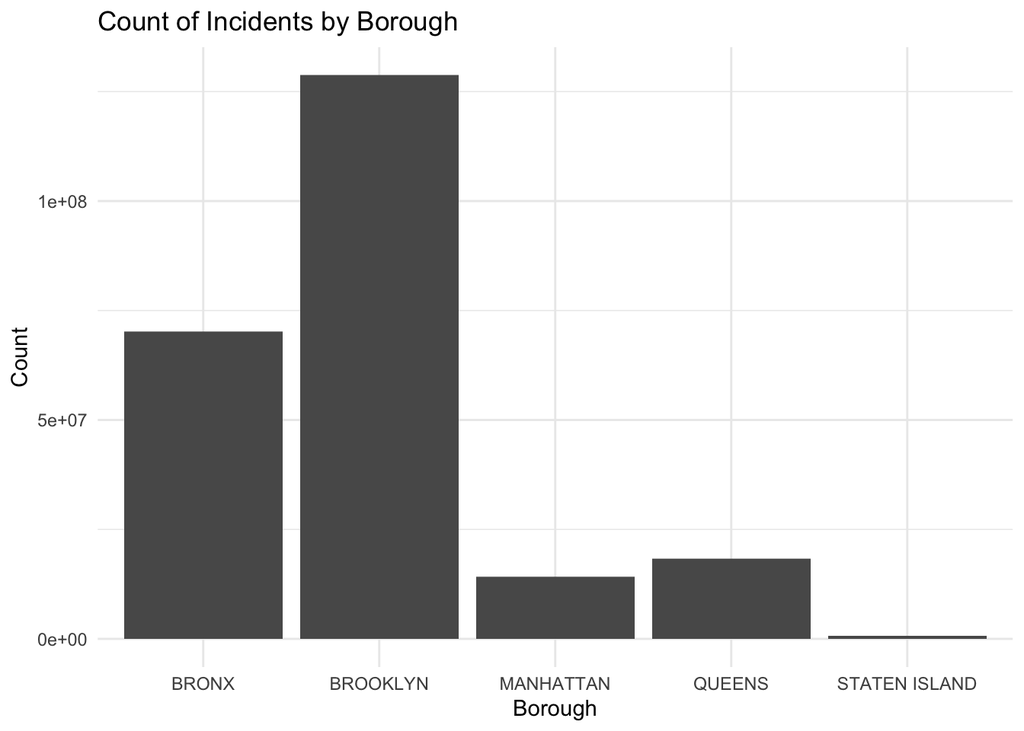

```r
ggplot(df, aes(x = BORO, y = BORO_COUNT)) + geom_bar(stat = "identity") + labs(x = "Borough", y = "Count", title = "Count of Incidents by Borough") + theme_minimal()
```

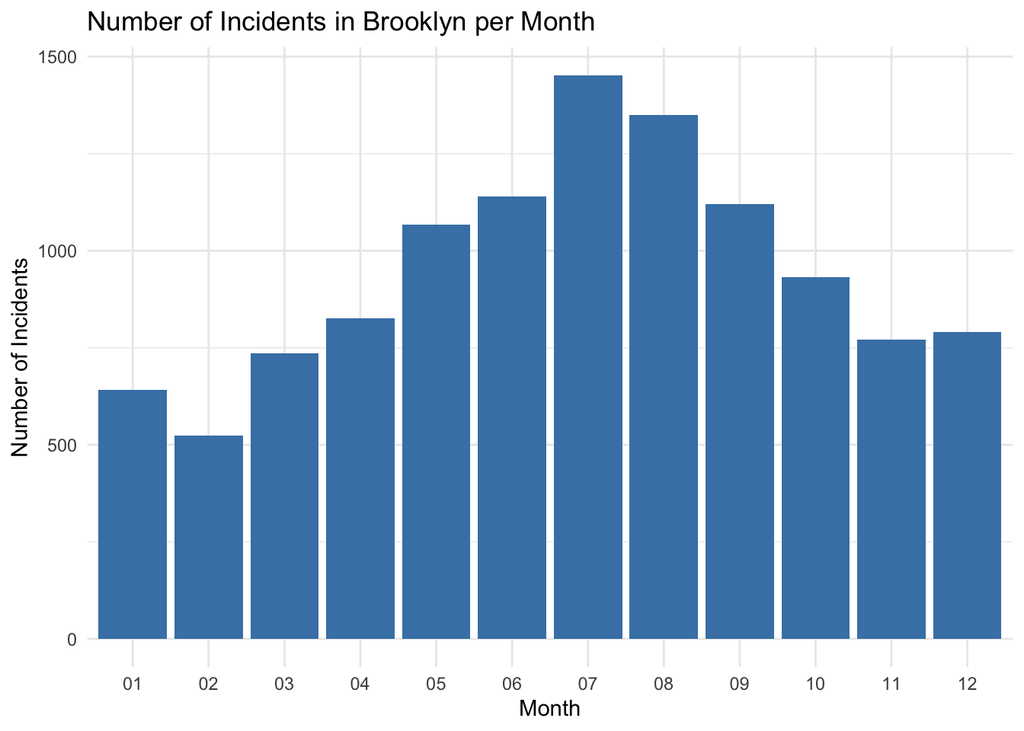

```r
brooklyn_data <- df %>%
  mutate(MONTH = substr(OCCUR_DATE, 1, 2)) %>%
  filter(BORO == "BROOKLYN") %>%
  group_by(MONTH) %>%
  summarise(INCIDENT_COUNT = n())

ggplot(brooklyn_data, aes(x = MONTH, y = INCIDENT_COUNT)) +
  geom_bar(stat = "identity", fill = "steelblue") +
  labs(title = "Number of Incidents in Brooklyn per Month", x = "Month", y = "Number of Incidents") +
  theme_minimal()
```

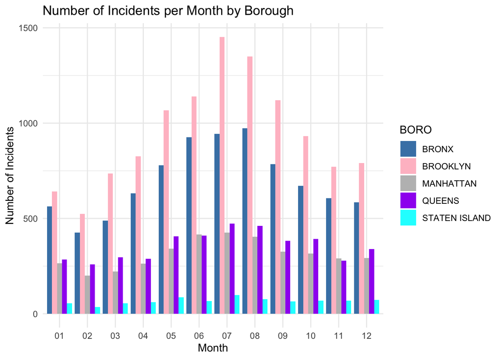

```r
monthly_counts <- df %>%
  mutate(MONTH = substr(OCCUR_DATE, 1, 2)) %>%
  group_by(MONTH, BORO) %>%
  summarise(INCIDENT_COUNT = n(), .groups = 'drop')

ggplot(MONTHLY_COUNTS, aes(x = MONTH, y = INCIDENT_COUNT, fill = BORO)) +
  geom_bar(stat = "identity", position = "dodge") +
  labs(title = "Number of Incidents per Month by Borough", x = "Month", y = "Number of Incidents") +
  scale_fill_manual(values = c("BRONX" = "steelblue", "MANHATTAN" = "grey",
                               "BROOKLYN" = "pink", "QUEENS" = "purple",
                               "STATEN ISLAND" = "cyan")) +
  theme_minimal()
```

The three graphs above raise several questions I’d like to explore further. In the first graph, Brooklyn had the highest number of shooting incidents from 2006 to 2022 and Staten Island had the fewest. This leads me to ask: what is the ratio of shootings to population in each borough and does individuals financial situation correlate to shootings?

The third graph illustrates shooting incidents per month for all boroughs. However, it is not totally clear if the amount of shootings is significantly different for summer vs. winter months in all boroughs. Based on this visualization, it would be helpful to conduct more statistical analyses to determine if there is a significant difference in shooting incidents by season.

```r
df$OCCUR_DATE <- as.Date(df$OCCUR_DATE, format = "%m/%d/%Y")

# Create a new month and season column for winter (December, January, February) and summer (June, July, August)
df <- df %>%
  mutate(MONTH = month(OCCUR_DATE),
         SEASON = case_when(
           MONTH %in% c(6, 7, 8) ~ "Summer",
           MONTH %in% c(12, 1, 2) ~ "Winter",
           TRUE ~ NA_character_))
# Define the boroughs
boroughs <- c("BRONX", "BROOKLYN", "MANHATTAN", "QUEENS", "STATEN ISLAND")

# Initialize a data frame to store results
season_counts <- data.frame(BORO = character(), SEASON = character(), COUNT = integer(), stringsAsFactors = FALSE)

for (boro in boroughs) {

  summer_count <- df %>%
    filter(BORO == boro & SEASON == "Summer") %>%
    summarise(COUNT = n()) %>%
    mutate(BORO = boro, SEASON = "Summer")

  winter_count <- df %>%
    filter(BORO == boro & SEASON == "Winter") %>%
    summarise(COUNT = n()) %>%
    mutate(BORO = boro, SEASON = "Winter")

  if (nrow(summer_count) > 0) {
    season_counts <- bind_rows(season_counts, summer_count)
  }

  if (nrow(winter_count) > 0) {
    season_counts <- bind_rows(season_counts, winter_count)
  }
}
# View the results
print(season_counts)
```

```
##             BORO SEASON COUNT
## 1          BRONX Summer  2842
## 2          BRONX Winter  1573
## 3       BROOKLYN Summer  3940
## 4       BROOKLYN Winter  1955
## 5      MANHATTAN Summer  1246
## 6      MANHATTAN Winter   759
## 7         QUEENS Summer  1344
## 8         QUEENS Winter   883
## 9  STATEN ISLAND Summer   241
## 10 STATEN ISLAND Winter   162
```

```r
# Top question: Is there a significant difference between incident counts and season for each borough.
#Set up a two way ANOVA to test this

incident_summary <- df %>%
  group_by(BORO, SEASON) %>%
  summarise(Incident_Count = n()) %>%
  ungroup()
# View the summarized data
head(incident_summary)
```

```
## # A tibble: 6 × 3
##   BORO     SEASON Incident_Count
##   <fct>    <chr>           <int>
## 1 BRONX    Summer           2842
## 2 BRONX    Winter           1573
## 3 BRONX    <NA>             3961
## 4 BROOKLYN Summer           3940
## 5 BROOKLYN Winter           1955
## 6 BROOKLYN <NA>             5451
```

```r
df_clean <- incident_summary %>% drop_na()
head(df_clean)
```

```
## # A tibble: 6 × 3
##   BORO      SEASON Incident_Count
##   <fct>     <chr>           <int>
## 1 BRONX     Summer           2842
## 2 BRONX     Winter           1573
## 3 BROOKLYN  Summer           3940
## 4 BROOKLYN  Winter           1955
## 5 MANHATTAN Summer           1246
## 6 MANHATTAN Winter            759
```

```r
poisson_model <- glm(Incident_Count ~ BORO + SEASON, data = df_clean, family = poisson)
summary(poisson_model)
```

```
##
## Call:
## glm(formula = Incident_Count ~ BORO + SEASON, family = poisson,
##     data = df_clean)
##
## Coefficients:
##                   Estimate Std. Error z value Pr(>|z|)
## (Intercept)        7.95150    0.01624  489.74   <2e-16 ***
## BOROBROOKLYN       0.28910    0.01990   14.53   <2e-16 ***
## BOROMANHATTAN     -0.78936    0.02693  -29.31   <2e-16 ***
## BOROQUEENS        -0.68435    0.02599  -26.33   <2e-16 ***
## BOROSTATEN ISLAND -2.39383    0.05204  -46.00   <2e-16 ***
## SEASONWinter      -0.58939    0.01708  -34.52   <2e-16 ***
## ---
## Signif. codes:  0 '***' 0.001 '**' 0.01 '*' 0.05 '.' 0.1 ' ' 1
##
## (Dispersion parameter for poisson family taken to be 1)
##
##     Null deviance: 8207.509  on 9  degrees of freedom
## Residual deviance:   39.136  on 4  degrees of freedom
## AIC: 139.01
##
## Number of Fisher Scoring iterations: 3
```

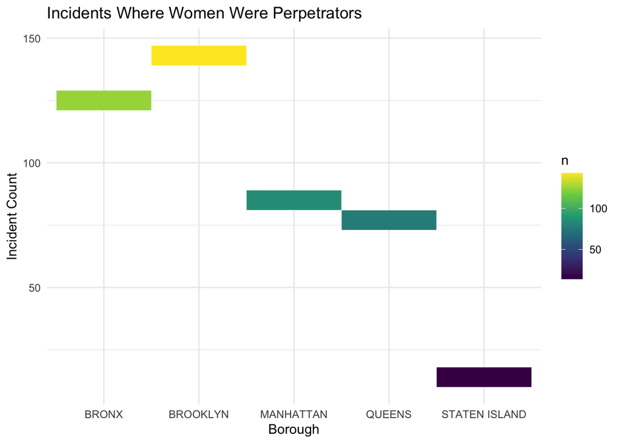

```r
# Count incidents for female perpetrators by borough
df_female_boro <- df %>%
  filter(PERP_SEX == "F") %>%
  count(BORO)
# Count incidents for male perpetrators by borough
df_male_boro <- df %>%
  filter(PERP_SEX == "M") %>%
  count(BORO)
# Plot heatmap for female perpetrators by borough
heatmap_female_boro <- ggplot(df_female_boro, aes(x = BORO, y = n, fill = n)) +
  geom_tile(color = "white") +
  scale_fill_viridis_c() +
  labs(title = "Incidents Where Women Were Perpetrators", x = "Borough", y = "Incident Count") +
  theme_minimal()
# Plot heatmap for male perpetrators by borough
heatmap_male_boro <- ggplot(df_male_boro, aes(x = BORO, y = n, fill = n)) +
  geom_tile(color = "white") +
  scale_fill_viridis_c() +
  labs(title = "Incidents Where Men Were Perpetrators", x = "Borough", y = "Incident Count") +
  theme_minimal()
# Display the heatmaps
heatmap_female_boro
```

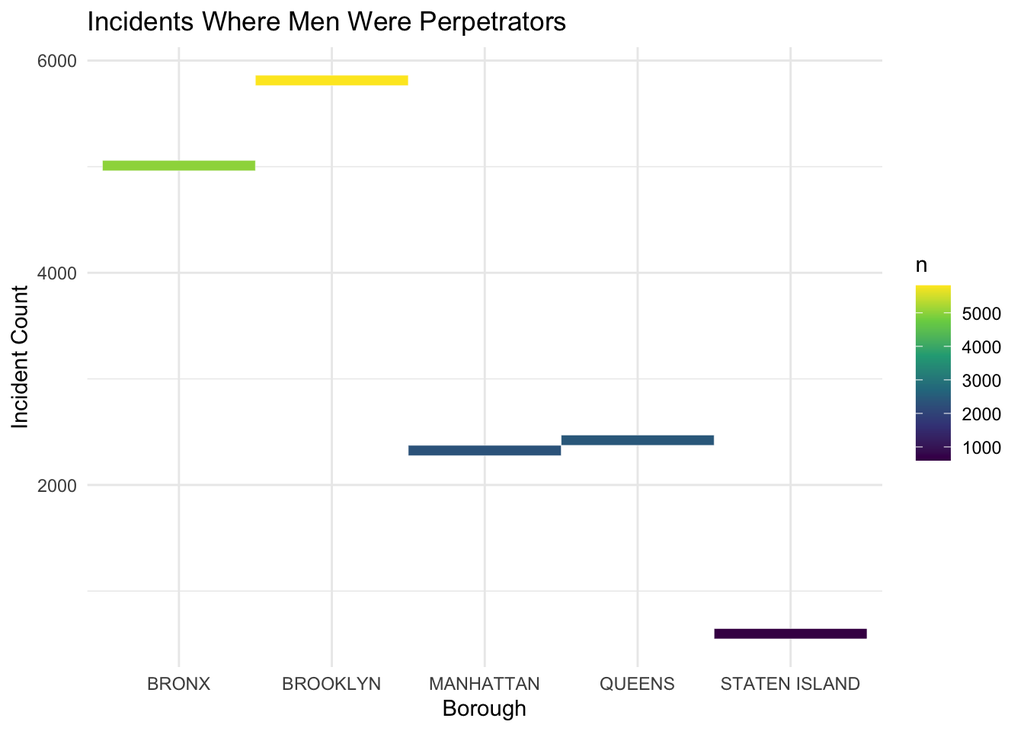

```r
heatmap_male_boro
```

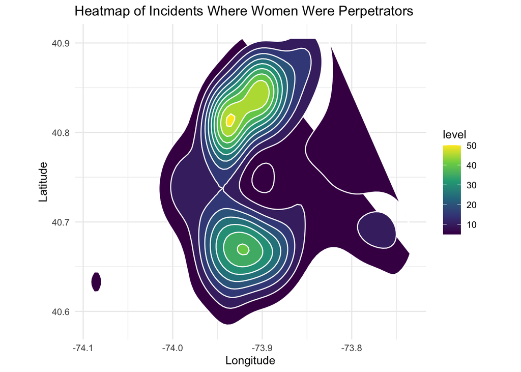

```r
df_female <- df %>%
  filter(PERP_SEX == "F", !is.na(Latitude), !is.na(Longitude),
         is.finite(Latitude), is.finite(Longitude))

df_male <- df %>%
  filter(PERP_SEX == "M", !is.na(Latitude), !is.na(Longitude),
         is.finite(Latitude), is.finite(Longitude))

heatmap_female <- ggplot(df_female, aes(x = Longitude, y = Latitude)) +
  stat_density_2d(aes(fill = ..level..), geom = "polygon", color = "white") +
  scale_fill_viridis_c() + # Color scale
  coord_equal() + # Keep map proportions correct
  labs(title = "Heatmap of Incidents Where Women Were Perpetrators",
       x = "Longitude", y = "Latitude") +
  theme_minimal()

# Display the heatmap for female perpetrators
heatmap_female
```

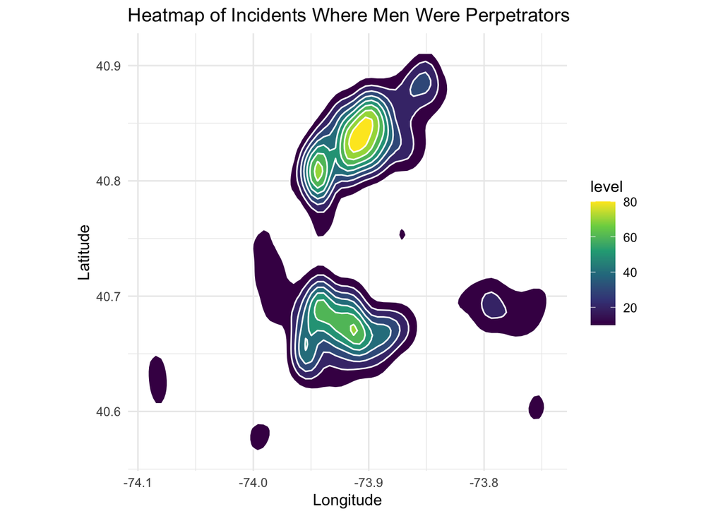

```r
heatmap_male <- ggplot(df_male, aes(x = Longitude, y = Latitude)) +
  stat_density_2d(aes(fill = ..level..), geom = "polygon", color = "white") +
  scale_fill_viridis_c() +
  coord_equal() +
  labs(title = "Heatmap of Incidents Where Men Were Perpetrators",
       x = "Longitude", y = "Latitude") +
  theme_minimal()

# Display the heatmap for male perpetrators
heatmap_male
```

The four heat maps appear to have more women than men perpetrators based on the width of the bars/colored area. However, after reviewing the two scales we can see that the opposite is true. This exemplifies the importance of choosing the best visualization tools to represent our data properly.

```r
leaflet_map <- leaflet() %>%
  addTiles() %>%
  setView(lng = -74.0060, lat = 40.7128, zoom = 12)

# Add points for female perpetrators
leaflet_map1 <- leaflet_map %>%
  addCircleMarkers(data = df_female,
                   lat = ~Latitude,
                   lng = ~Longitude,
                   color = "red",
                   radius = 3,
                   stroke = FALSE,
                   fillOpacity = 0.5,
                   popup = ~paste("Incident Date:", OCCUR_DATE))


# Add points for male perpetrators
leaflet_map <- leaflet_map %>%
  addCircleMarkers(data = df_male,
                   lat = ~Latitude,
                   lng = ~Longitude,
                   color = "blue",
                   radius = 3,
                   stroke = FALSE,
                   fillOpacity = 0.5,
                   popup = ~paste("Incident Date:", OCCUR_DATE))

# Display the maps

leaflet_map1
```

[interactive chart not shown]

```r
leaflet_map
```

[interactive chart not shown]

The two plots above, where incidents overlay the map of the city best represents the difference in women and men perpetrators. The red and blue dots represent specific incidents and the exact longitude and latitude where they occured. This can better help people identify which streets in specific boroughs may be the most dangerous. If we did not map all of this information then it would be easy to assume or have a bias against Brooklyn as it had the greatest amount of total incidents.

## Conclusion:

In this report I wrangled the data by first changing certain columns to factors. I then edited the time and date variables, so that they would be easier to interpret, and made a new column to represent the total amount of shooting incidents by borough.

The key things I wanted to determine was what borough had the most amount of shootings and which ones had the least amount.

I then wanted to determine if the month had any factor in the number of shootings that occurred. I first graphed the number of Brooklyn shootings by month, then used a comparative bar graph to show all of the boroughs next to each other.

At the end of my analysis I made four heat maps to compare the gender of the perpetrators in New York City. I then made two interactive maps so users can view exact locations and the date where shootings occurred. Had I not created the last two interactive maps it would appear that there were more women perpetrators than men, which is not the case. Furthermore, it would have gave a false bias on what areas have had the most shootings. For example, not every neighborhood in Brooklyn had high concentration of shootings. Some of the south west neighborhoods in Brooklyn had fewer shootings neighborhoods in Staten Island.

By using the interactive maps people can determine exact locations where the shooting occurred which will hopefully lead to more informed travel and living decisions.

I hope you enjoyed this data analysis on the NYPD shooting incident dataset.